# Содержание

#### Конверсия и удержание пользователей

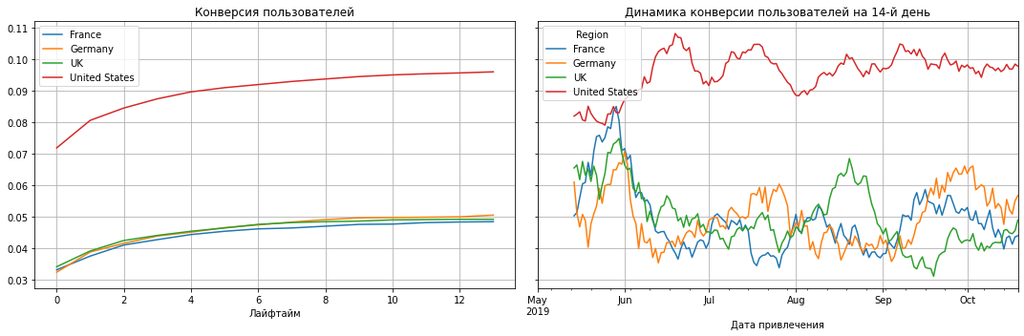

```python
# смотрим конверсию с разбивкой по странам
conversion_raw, conversion_grouped, conversion_history = get_conversion(
    profiles, purchases, observation_date, horizon_days, dimensions=['Region']
)

plot_conversion(conversion_grouped, conversion_history, horizon_days, window=14)
```

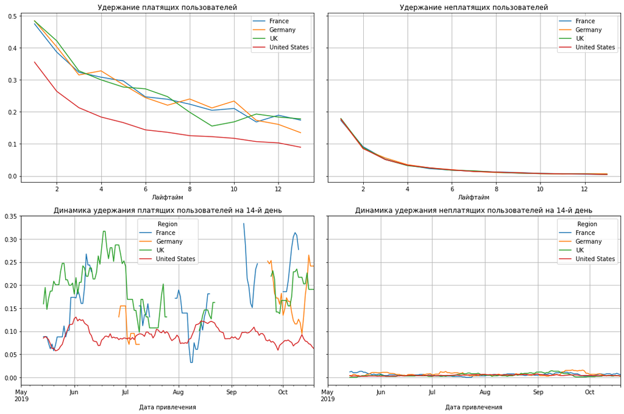

```python
# смотрим удержание с разбивкой по странам
dimensions=['Region']
retention_raw, retention_grouped, retention_history = get_retention(
    profiles, visits, observation_date, horizon_days, dimensions=dimensions
)

plot_retention(retention_grouped, retention_history, horizon_days, window=14)
```

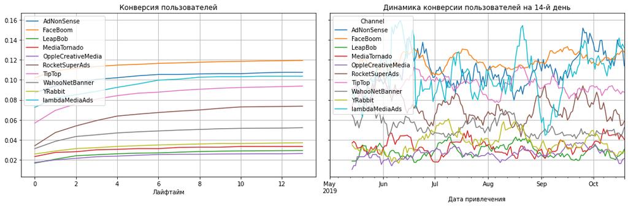

```python
# Посмотрим также конверсию с разбивкой по каналам привлечения
conversion_raw, conversion_grouped, conversion_history = get_conversion(
    profiles, purchases, observation_date, horizon_days, dimensions=['Channel']
)

plot_conversion(conversion_grouped, conversion_history, horizon_days, window=14)
```

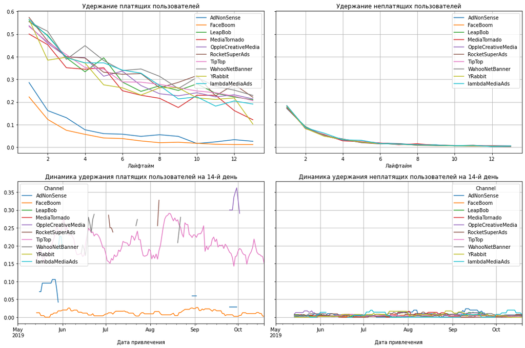

```python
# И удержание по каналам привлечения
retention_raw, retention_grouped, retention_history = get_retention(
    profiles, visits, observation_date, horizon_days, dimensions=['Channel']
)

plot_retention(retention_grouped, retention_history, horizon_days, window=14)
```

**Комментарий ревьюера v.2** 👍 Вот тут хорошо видно, что причина низкого удержания пользователей из `США` - низкое удержание пользователеЙ, привлеченных по каналу `FaceBoom`. У этого канала привлечение на уровне неплатящих пользователей.

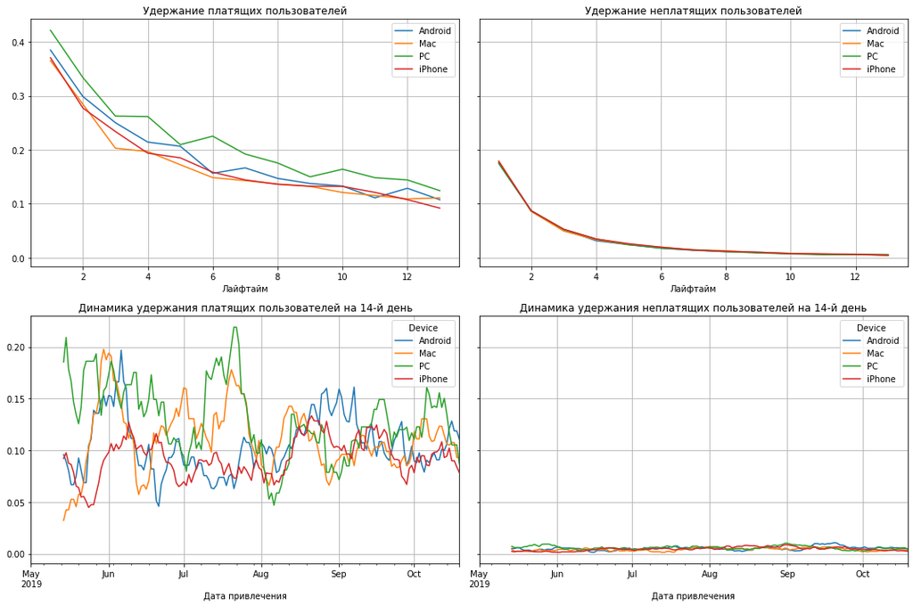

```python
# И удержание в разрезе типов устройств
retention_raw, retention_grouped, retention_history = get_retention(
    profiles, visits, observation_date, horizon_days, dimensions=['Device']
)

plot_retention(retention_grouped, retention_history, horizon_days, window=14)
```

То, что мы уже выяснили на 3 шаге, подтверждается: пользователи из США лучше конвертируются. Их конверсия выросла одновременно с расходами на рекламу в начале июне, однако достигнув уровня около 10%, продолжила колебаться вокруг этого уровня. Конверсия клиентов из других стран остается в диапазоне 4-6%, периодически увеличиваясь (особенно в Германии в середине лета).  
При этом удержание платящих пользователей из США - стабильно худшее из всех стран. Удержание клиентов из Франции и Великобритании подвержено сильным колебаниям из месяца в месяц. Из платформ лучшее удержание у пользоваталей PC.  
Лучшая конверсия в покупку - у пользователей из каналов FaceBoom, AdNonSense и lambdaMediaArts.